# R Notebook

Data paragraph:

The data for this research comes from a built-in R dataset based on the 1974 Motor Trend US data. It contains fuel consumption, design, and performance information for 32 automobile models from the 1973-1974 model years. The data is observational data compiled by Motor Trend. The unit of observation is the automobile model. (source: http://www.sthda.com/english/wiki/r-built-in-data-sets#mtcars-motor-trend-car-road-tests)

```r
my_data <- mtcars
head(my_data)
```

|  | mpg | cyl | disp | hp | drat | wt | qsec | vs | am | gear | carb |
| --- | --- | --- | --- | --- | --- | --- | --- | --- | --- | --- | --- |
| Mazda RX4 | 21.0 | 6 | 160 | 110 | 3.90 | 2.620 | 16.46 | 0 | 1 | 4 | 4 |
| Mazda RX4 Wag | 21.0 | 6 | 160 | 110 | 3.90 | 2.875 | 17.02 | 0 | 1 | 4 | 4 |
| Datsun 710 | 22.8 | 4 | 108 | 93 | 3.85 | 2.320 | 18.61 | 1 | 1 | 4 | 1 |
| Hornet 4 Drive | 21.4 | 6 | 258 | 110 | 3.08 | 3.215 | 19.44 | 1 | 0 | 3 | 1 |
| Hornet Sportabout | 18.7 | 8 | 360 | 175 | 3.15 | 3.440 | 17.02 | 0 | 0 | 3 | 2 |
| Valiant | 18.1 | 6 | 225 | 105 | 2.76 | 3.460 | 20.22 | 1 | 0 | 3 | 1 |

```r
NA
```

Variables paragraph:

```r
summary(my_data$mpg)
```

```
   Min. 1st Qu.  Median    Mean 3rd Qu.    Max.
  10.40   15.43   19.20   20.09   22.80   33.90
```

```r
sd(my_data$mpg)
```

```
[1] 6.026948
```

```r
summary(my_data$wt)
```

```
   Min. 1st Qu.  Median    Mean 3rd Qu.    Max.
  1.513   2.581   3.325   3.217   3.610   5.424
```

```r
sd(my_data$wt)
```

```
[1] 0.9784574
```

```r
summary(my_data$hp)
```

```
   Min. 1st Qu.  Median    Mean 3rd Qu.    Max.
   52.0    96.5   123.0   146.7   180.0   335.0
```

```r
sd(my_data$hp)
```

```
[1] 68.56287
```

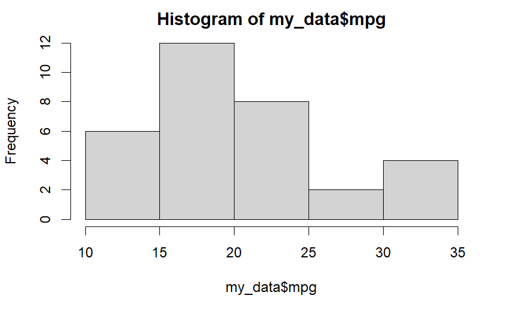

```r
hist(my_data$mpg)
```

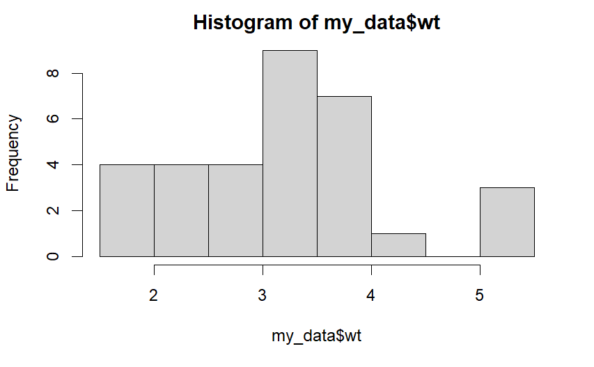

```r
hist(my_data$wt)
```

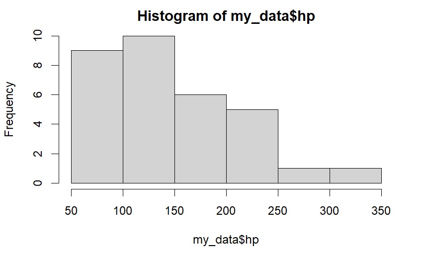

```r
hist(my_data$hp)
```

Relationship paragraph:

I theorize that both higher vehicle weight and higher horsepower will detract from fuel efficiency. The correlation coefficient for hp and mpg is -0.7761684. The correlation coefficient for wt and mpg is -0.8676594. Both are consistent with my theory. There may be some issue with multicollinearity as the correlation between hp and wt is 0.6587479. This is not surprising as heavier vehicles require more powerful engines. A future study should examine the interaction between weight and hp on mpg.

```r
cor(my_data$hp,my_data$mpg)
```

```
[1] -0.7761684
```

```r
cor(my_data$wt,my_data$mpg)
```

```
[1] -0.8676594
```

```r
cor(my_data$hp,my_data$wt)
```

```
[1] 0.6587479
```

Regression paragraph:

I performed three OLS regressions all using mpg as the dependent variable, two single variable regressions using hp and wt individually, and one multiple regression using hp and wt as explanatory variables. Here I describe the results of the multivariate regression. The intercept, 37.22727 mpg, was significant at the .01 level. Both horsepower and weight had negative relationships with fuel efficiency that were significant at the .01 level. **The null hypothesis is rejected with regard to both weight and horsepower.** For each additional unit of horsepower, fuel efficiency decreased by .03177 miles per gallon, all else being equal. The standard error was .00903 and the t-value was -3.519. For each additional one thousand pounds of weight, fuel efficiency decreased by 3.87783 miles per gallon all else being equal. The standard error was 0.63273 and the t-value was -6.129. The model is significant, with a p-value less than .01. With an adjusted R-squared of 0.8148, the model explains over 80% of fuel efficiency.

```r
wt_model <- lm(mpg ~ wt, data = my_data)
summary(wt_model)
```

```
Call:
lm(formula = mpg ~ wt, data = my_data)

Residuals:
    Min      1Q  Median      3Q     Max
-4.5432 -2.3647 -0.1252  1.4096  6.8727

Coefficients:
            Estimate Std. Error t value Pr(>|t|)
(Intercept)  37.2851     1.8776  19.858  < 2e-16 ***
wt           -5.3445     0.5591  -9.559 1.29e-10 ***
---
Signif. codes:
0 ‘***’ 0.001 ‘**’ 0.01 ‘*’ 0.05 ‘.’ 0.1 ‘ ’ 1

Residual standard error: 3.046 on 30 degrees of freedom
Multiple R-squared:  0.7528,    Adjusted R-squared:  0.7446
F-statistic: 91.38 on 1 and 30 DF,  p-value: 1.294e-10
```

```r
hp_model <- lm(mpg ~ hp, data = my_data)
summary(hp_model)
```

```
Call:
lm(formula = mpg ~ hp, data = my_data)

Residuals:
    Min      1Q  Median      3Q     Max
-5.7121 -2.1122 -0.8854  1.5819  8.2360

Coefficients:
            Estimate Std. Error t value Pr(>|t|)
(Intercept) 30.09886    1.63392  18.421  < 2e-16 ***
hp          -0.06823    0.01012  -6.742 1.79e-07 ***
---
Signif. codes:
0 ‘***’ 0.001 ‘**’ 0.01 ‘*’ 0.05 ‘.’ 0.1 ‘ ’ 1

Residual standard error: 3.863 on 30 degrees of freedom
Multiple R-squared:  0.6024,    Adjusted R-squared:  0.5892
F-statistic: 45.46 on 1 and 30 DF,  p-value: 1.788e-07
```

```r
full_model <- lm(mpg ~ hp + wt, data = my_data)
summary(full_model)
```

```
Call:
lm(formula = mpg ~ hp + wt, data = my_data)

Residuals:
   Min     1Q Median     3Q    Max
-3.941 -1.600 -0.182  1.050  5.854

Coefficients:
            Estimate Std. Error t value Pr(>|t|)
(Intercept) 37.22727    1.59879  23.285  < 2e-16 ***
hp          -0.03177    0.00903  -3.519  0.00145 **
wt          -3.87783    0.63273  -6.129 1.12e-06 ***
---
Signif. codes:
0 ‘***’ 0.001 ‘**’ 0.01 ‘*’ 0.05 ‘.’ 0.1 ‘ ’ 1

Residual standard error: 2.593 on 29 degrees of freedom
Multiple R-squared:  0.8268,    Adjusted R-squared:  0.8148
F-statistic: 69.21 on 2 and 29 DF,  p-value: 9.109e-12
```